# Analisis Data Film IMDb

Gian Martin D. (6181801015)  
Arthur Everardus F. (6181801035)  
Michael Alvino (6181801041)  
Yalvi Hidayat (6181801044)

3/21/2021

# Deskripsi Dataset

Dataset yang kami ambil memiliki nama **IMDB-Movie-Data.csv** yang berisikan database film bedasarkan situs laman IMDb. IMDb itu tersendiri adalah situs yang menampilkan deskripsi film, rating film, dan para aktor juga. Dataset ini memiliki **12 kolom atribut** yang terdiri dari *Rank, Title, Description, Director, Year, Runtime, Rating, Votes, Revenue, dan Metascore*. Dataset ini juga memiliki jumlah baris sebanyak **1000 baris** dan memiliki **ukuran file sebesar 303 kb**. Dataset ini belumlah bersih karena terdapat nilai NA yang dapat mempengaruhi kesimpulan dalam menarik kesimpulan bisnis.

Berikut penjelasan singkat tiap kolom dalam dataset IMDB-Movie-Data.csv:

| Rank | : Urutan data yang bersifat numerik |
| --- | --- |
| Title | : Judul film |
| Genre | : Jenis film |
| Description | : Sinopsis film |
| Director | : Sutradara film |
| Actors | : Pemeran film yang dapat lebih dari 1 pemeran |
| Year | : Tahun rilis film |
| Runtime | : Durasi lamanya film dalam satuan menit |
| Rating | : Penilaian yang diberikan oleh user IMDB dengan skala 1 – 10 |
| Votes | : Jumlah user IMDB yang memberikan rating suatu film |
| Revenue | : Penghasilan yang dihasilkan dari film dalam satuan juta Dollar Amerika |
| Metascore | : Penilaian dari kritikus dengan skala 0 – 100 |

# Persiapan awal

```r
#Import library yang diperlukan
library(ggplot2)
library(dplyr)
library(tidyr)

#Import dataset yang digunakan
data <- read.csv("IMDB-Movie-Data.csv")
head(data)
```

|  | Rank | Title | Genre | Description | Director | Actors | Year | Runtime..Minutes. | Rating | Votes | Revenue..Millions. | Metascore |
| --- | --- | --- | --- | --- | --- | --- | --- | --- | --- | --- | --- | --- |
| 1 | 1 | Guardians of the Galaxy | Action,Adventure,Sci-Fi | A group of intergalactic criminals are forced to work together to stop a fanatical warrior from taking control of the universe. | James Gunn | Chris Pratt, Vin Diesel, Bradley Cooper, Zoe Saldana | 2014 | 121 | 8.1 | 757074 | 333.13 | 76 |
| 2 | 2 | Prometheus | Adventure,Mystery,Sci-Fi | Following clues to the origin of mankind, a team finds a structure on a distant moon, but they soon realize they are not alone. | Ridley Scott | Noomi Rapace, Logan Marshall-Green, Michael Fassbender, Charlize Theron | 2012 | 124 | 7.0 | 485820 | 126.46 | 65 |
| 3 | 3 | Split | Horror,Thriller | Three girls are kidnapped by a man with a diagnosed 23 distinct personalities. They must try to escape before the apparent emergence of a frightful new 24th. | M. Night Shyamalan | James McAvoy, Anya Taylor-Joy, Haley Lu Richardson, Jessica Sula | 2016 | 117 | 7.3 | 157606 | 138.12 | 62 |
| 4 | 4 | Sing | Animation,Comedy,Family | In a city of humanoid animals, a hustling theater impresario's attempt to save his theater with a singing competition becomes grander than he anticipates even as its finalists' find that their lives w… | Christophe Lourdelet | Matthew McConaughey,Reese Witherspoon, Seth MacFarlane, Scarlett Johansson | 2016 | 108 | 7.2 | 60545 | 270.32 | 59 |
| 5 | 5 | Suicide Squad | Action,Adventure,Fantasy | A secret government agency recruits some of the most dangerous incarcerated super-villains to form a defensive task force. Their first mission: save the world from the apocalypse. | David Ayer | Will Smith, Jared Leto, Margot Robbie, Viola Davis | 2016 | 123 | 6.2 | 393727 | 325.02 | 40 |
| 6 | 6 | The Great Wall | Action,Adventure,Fantasy | European mercenaries searching for black powder become embroiled in the defense of the Great Wall of China against a horde of monstrous creatures. | Yimou Zhang | Matt Damon, Tian Jing, Willem Dafoe, Andy Lau | 2016 | 103 | 6.1 | 56036 | 45.13 | 42 |

# 1. Berapa jumlah Genre yang dihasilkan per tahunnya?

Kami akan menghitung berapa film yang dihasilkan untuk tiap genre per tahunnya, guna melihat tren kenaikan atau penurunan produksi film.

Diperlukan Tabel seperti berikut:

- DataGenreYear(Year, Genre, Count)
- DataGenreTotal(Genre, Count)

Keterangan:

- - Year : Merupakan tahun rilis dari sebuah film. Range yang digunakan adalah tahun 2006 – 2016
  - Genre : Merupakan jenis/kategori film
  - Count : Jumlah Film per Genre

# Penyiapan Data

Dari dataframe yang setiap baris di kolom Genre-nya memiliki lebih dari satu genre, akan dibuat 3 kolom baru (jumlah genre untuk satu film tidak mungkin melebihi 3). Setiap kolom baru yang dibuat (Genre1, Genre2, Genre3) akan berisi hasil pemisahan Genre.

```r
i <- 1
while (i <= nrow(data)) {
  genres <- unlist(strsplit(data$Genre[i], ",", fixed = TRUE))
  data$Genre1[i] <- genres[1]
  data$Genre2[i] <- genres[2]
  data$Genre3[i] <- genres[3]
  i <- i + 1
}
#Tampilkan kolom: Title, Genre, Genre1, Genre2, Genre3
head(data %>% select(Title, Genre, Genre1, Genre2, Genre3) %>% arrange(Title))
```

|  | Title | Genre | Genre1 | Genre2 | Genre3 |
| --- | --- | --- | --- | --- | --- |
| 1 | (500) Days of Summer | Comedy,Drama,Romance | Comedy | Drama | Romance |
| 2 | 10 Cloverfield Lane | Drama,Horror,Mystery | Drama | Horror | Mystery |
| 3 | 10 Years | Comedy,Drama,Romance | Comedy | Drama | Romance |
| 4 | 12 Years a Slave | Biography,Drama,History | Biography | Drama | History |
| 5 | 127 Hours | Adventure,Biography,Drama | Adventure | Biography | Drama |
| 6 | 13 Hours | Action,Drama,History | Action | Drama | History |

# Penyiapan Data (2)

Buat dataframe baru dengan menggabungkan Genre dari 3 kolom ke satu kolom dengan menambahkan 1 baris untuk tiap Genre. Untuk film yang memiliki lebih dari 1 genre akan muncul sebanyak jumlah genre yang dimiliki film tersebut.

```r
dataGenre1 <- data.frame(data$Title, data$Year, data$Genre1)
colnames(dataGenre1) <- c("Title", "Year", "Genre")

dataGenre2 <- data.frame(data$Title, data$Year, data$Genre2)
colnames(dataGenre2) <- c("Title", "Year", "Genre")
dataGenre2 <- dataGenre2 %>% drop_na(Genre)

dataGenre3 <- data.frame(data$Title, data$Year, data$Genre3)
colnames(dataGenre3) <- c("Title", "Year", "Genre")
dataGenre3 <- dataGenre3 %>% drop_na(Genre)

dataGenre <- bind_rows(dataGenre1, dataGenre2, dataGenre3)
dataGenre %>% arrange(Title)
```

| Title | Year | Genre |
| --- | --- | --- |
| (500) Days of Summer | 2009 | Comedy |
| (500) Days of Summer | 2009 | Drama |
| (500) Days of Summer | 2009 | Romance |
| 10 Cloverfield Lane | 2016 | Drama |
| 10 Cloverfield Lane | 2016 | Horror |
| 10 Cloverfield Lane | 2016 | Mystery |
| 10 Years | 2011 | Comedy |
| 10 Years | 2011 | Drama |
| 10 Years | 2011 | Romance |
| 12 Years a Slave | 2013 | Biography |

[output cut: 2545 more lines]

# Penyiapan Data (3)

Kelompokkan data berdasarkan Tahun dan Genre, lalu hitung jumlah film yang dihasilkan per tiap kategori.

```r
dataGenreYear <- dataGenre %>%
                  group_by(Year, Genre) %>%
                  summarise(Count = n())

dataGenreYear
```

| Year | Genre | Count |
| --- | --- | --- |
| 2006 | Action | 11 |
| 2006 | Adventure | 13 |
| 2006 | Animation | 2 |
| 2006 | Biography | 3 |
| 2006 | Comedy | 12 |
| 2006 | Crime | 7 |
| 2006 | Drama | 26 |
| 2006 | Family | 1 |
| 2006 | Fantasy | 6 |
| 2006 | History | 1 |

[output cut: 185 more lines]

# Analisis Data

Dibuat plot untuk menunjukan jumlah film yang diproduksi untuk setiap genre tiap tahunnya.

```r
allGenre <- unique(dataGenreYear$Genre)

for(genre_ in allGenre){
  dataOneGenre <- dataGenreYear %>% filter(Genre == sprintf("%s", genre_))
  print(ggplot(dataOneGenre)+
          geom_col(aes(x = factor(Year, levels = 2006:2016), y = Count), fill="cadetblue1")+
          geom_text(aes(label=as.integer(Count), x = factor(Year, levels = 2006:2016), y = Count))+
          scale_x_discrete(breaks=factor(2006:2016), drop=FALSE)+
          theme(axis.text=element_text(size=14), axis.title=element_text(size=18), plot.title = element_text(size = 24, face = "bold"))+
          ggtitle(sprintf(genre_))+
          xlab("Tahun")+
          ylab("Jumlah film"))
}
```

## Plot untuk Jumlah Film yang Dihasilkan setiap Genre per Tahun

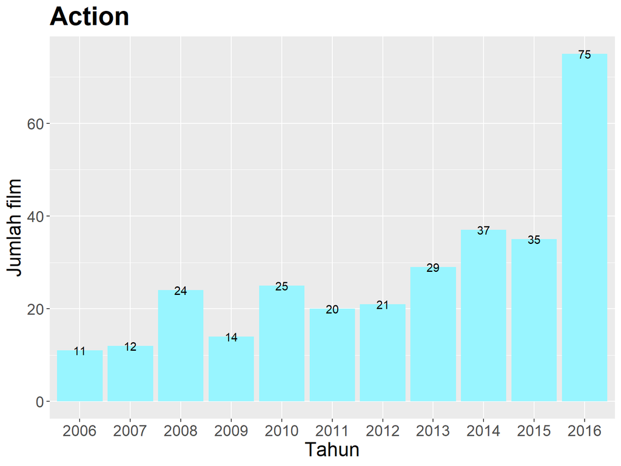

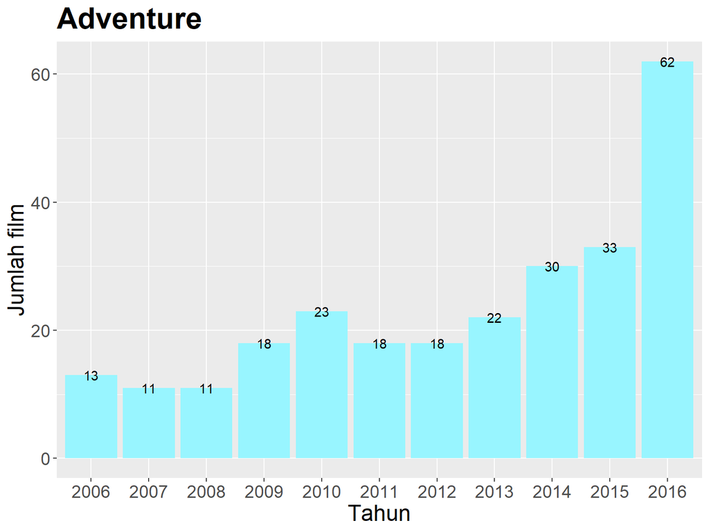

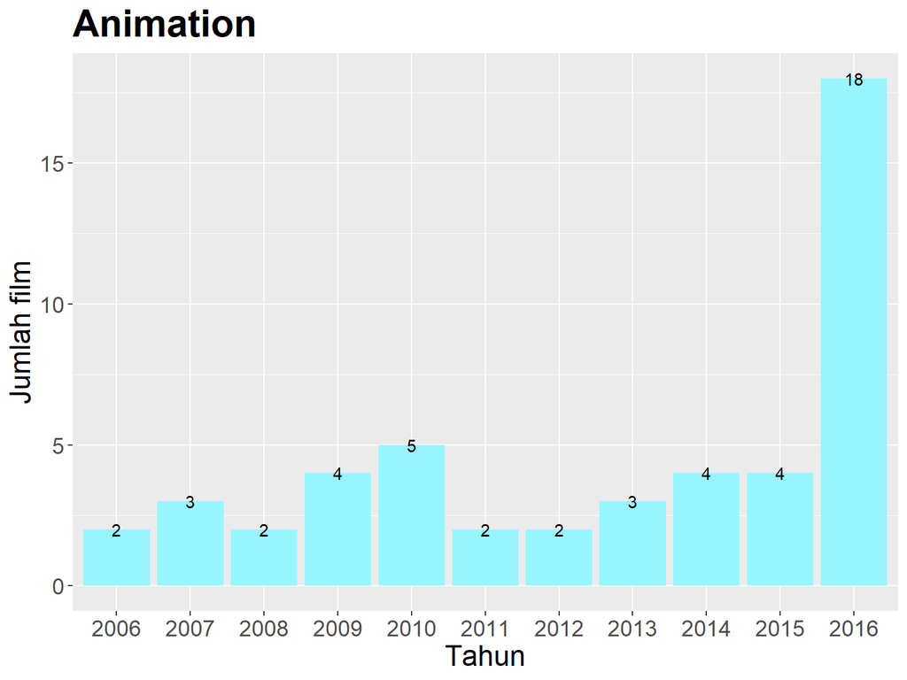

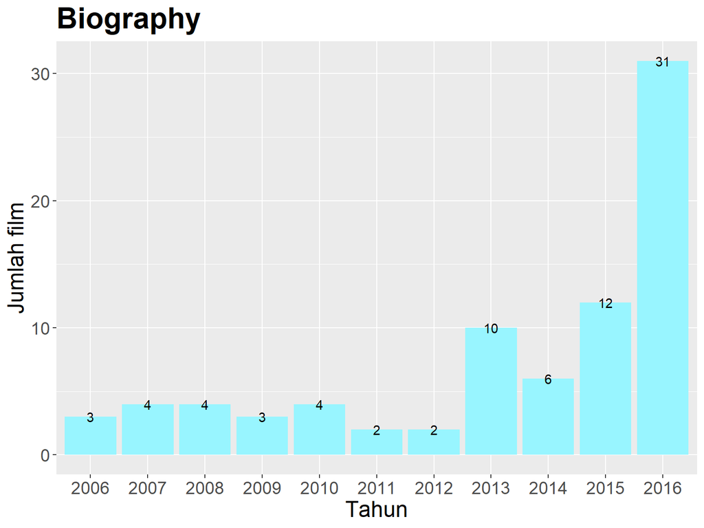

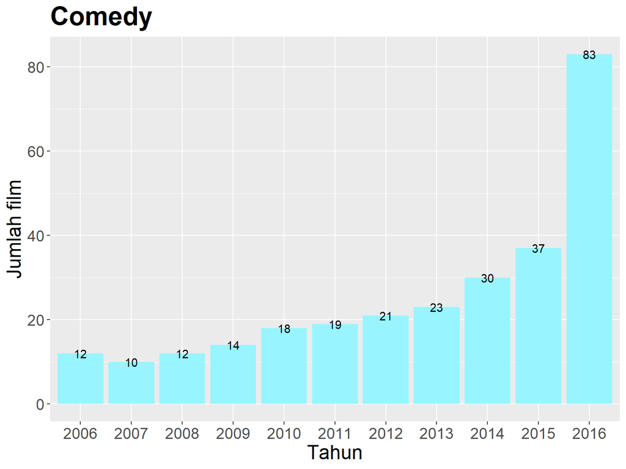

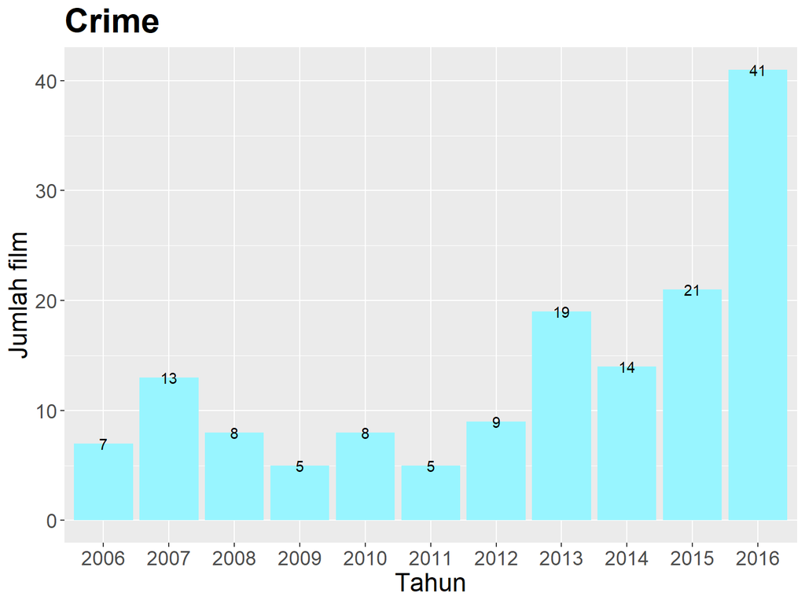

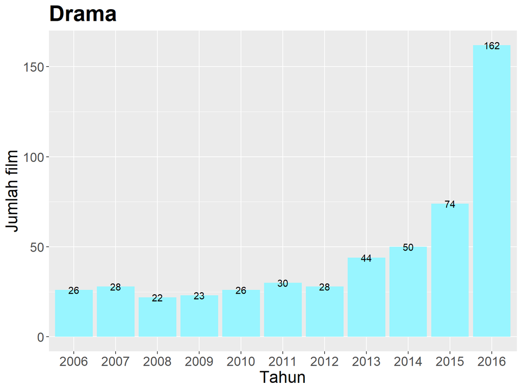

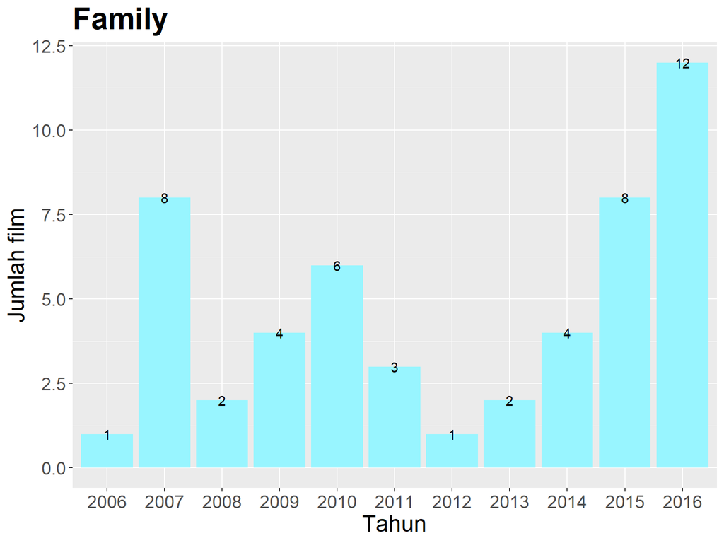

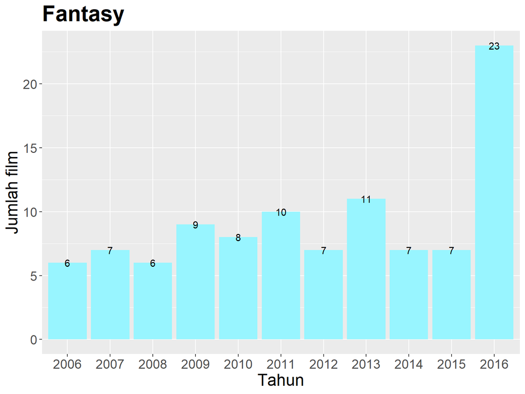

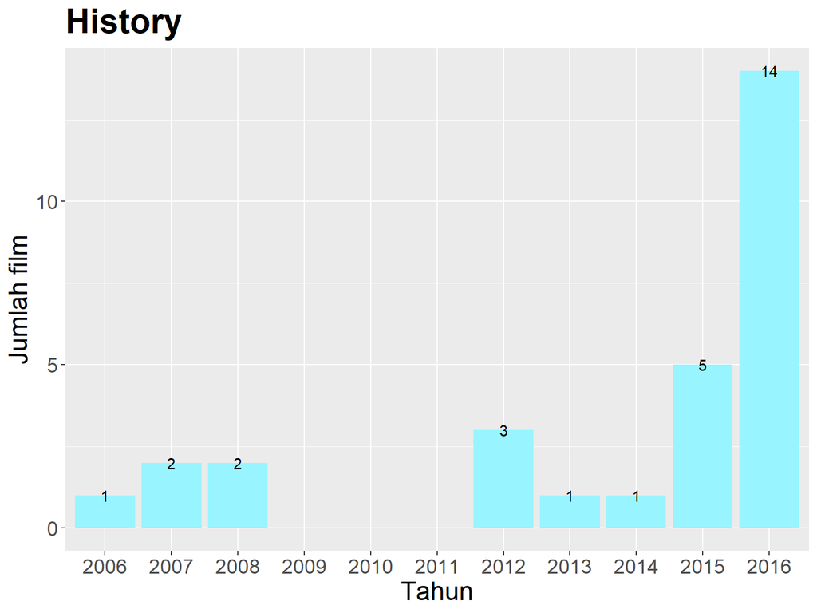

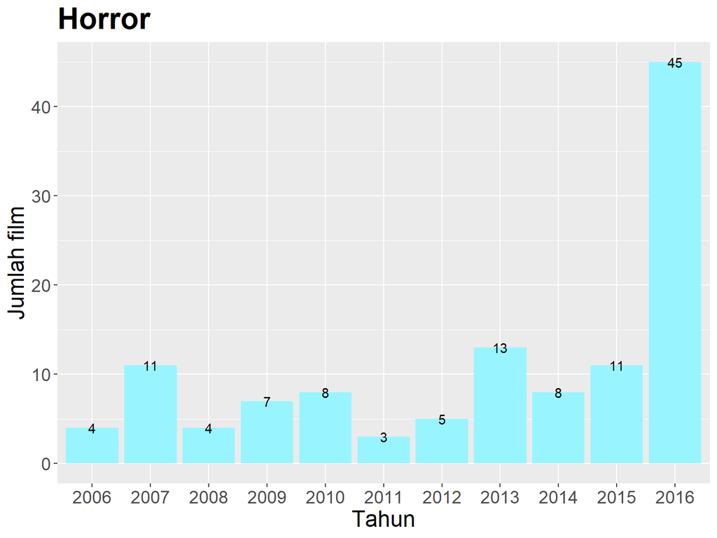

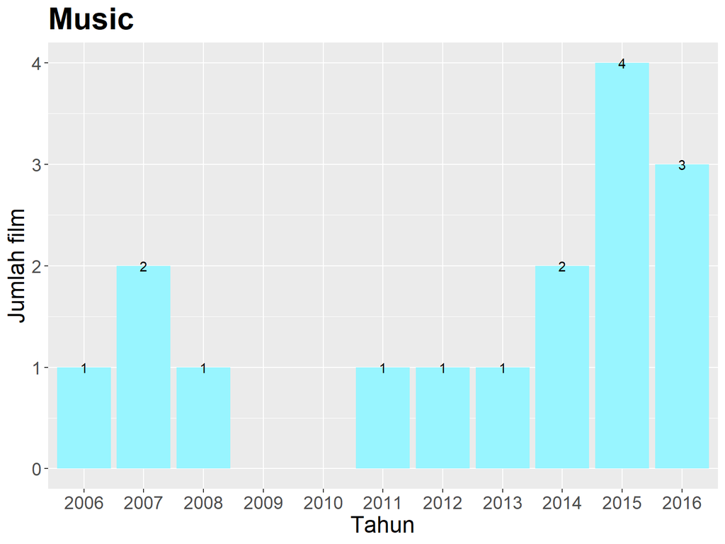

[8 more figures not shown]

# Penyiapan Data (4)

Buat dataframe untuk menghitung jumlah film yang dihasilkan untuk tiap genre dari seluruh tahun.

```r
dataGenreTotal <- dataGenreYear %>%
  group_by(Genre) %>%
  summarise(Count = sum(Count))

dataGenreTotal
```

| Genre | Count |
| --- | --- |
| Action | 303 |
| Adventure | 259 |
| Animation | 49 |
| Biography | 81 |
| Comedy | 279 |
| Crime | 150 |
| Drama | 513 |
| Family | 51 |
| Fantasy | 101 |
| History | 29 |

[output cut: 10 more lines]

# Analisis Data (2)

Kami membuat barplot horizontal yang menunjukkan total jumlah film bedasarkan genre. Untuk y-label adalah genre film. Untuk x-label menggunakan count yang merupakan banyaknya jumlah film. Berikut barplot yang kami buat:

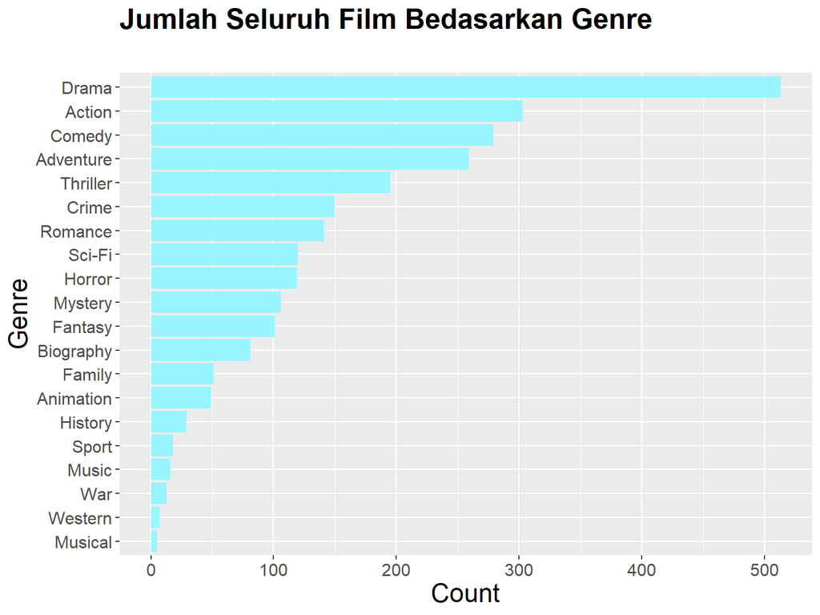

```r
ggplot(dataGenreTotal, aes(x = reorder(Genre, Count), y = Count))+
  geom_bar(stat = 'identity' , fill = 'cadetblue1')+
    coord_flip()+
    xlab("Genre")+
  ylab("Count")+
  theme(axis.text=element_text(size=12), axis.title=element_text(size=18), plot.title = element_text(size = 20, face = "bold"))+
  ggtitle("Jumlah Seluruh Film Bedasarkan Genre\n")
```

# Insight dan Manfaat

Dari Visualisasi plot-plot yang kami sudah buat didapatkan beberapa insight:

- Drama menjadi genre yang paling banyak dipilh sebagai genre untuk sebuah film, disusul Action dan Comedy. Genre Musical dan Western jarang dibuat sebagai film.
- Produksi film pada tahun 2016 meroket daripada tahun-tahun sebelumnya, terutama pada film-film di genre Action, Drama, Adventure, Animation, Biography, Comedy, Drime, Horror, dan History
- Ada beberapa genre yang tidak tercatat—atau bisa saja tidak ada film di tahun itu diproduksi. Berikut Rinciannya:
  - 2006: Western, Musical
  - 2007: Western, War, Sport
  - 2008: Western
  - 2009: Western, Musical, Music, History
  - 2010: Musical, Sport, Music, History
  - 2011: Western, Musical, War, History
  - 2012: War, Sport
  - 2013: Musical, War
  - 2014: Musical
  - 2015: Musical
  - 2016: Musical

# Penggalian Insight Baru

Dari analisis yang telah dilakukan didapat beberapa insight seperti yang sudah dipaparkan. Dari insight-insight tersebut kami berusaha untuk menggali lebih dalam untuk mendapatkan insight baru, dengan melihat bagaimana hubungan antara pendapatan (Revenue) yang dihasilkan oleh film dan jumlah film yang diproduksi.

Untuk itu diperlukan tabel dengan bentuk sebagai berikut:

- DataGenreYear(Year, Genre, Count, MeanRev)
- DataGenreTotal(Genre, Count, MeanRev)

Keterangan:

- - Year : Merupakan tahun rilis dari sebuah film. Range yang digunakan adalah tahun 2006 – 2016
  - Genre : Merupakan jenis/kategori film
  - Count : Jumlah Film per Genre
  - MeanRev : Rata-rata pendapatan untuk tiap kategori

# Penyiapan Data

Dari dataframe yang setiap baris di kolom Genre-nya memiliki lebih dari satu genre, akan dibuat 3 kolom baru (jumlah genre untuk satu film tidak mungkin melebihi 3). Setiap kolom baru yang dibuat (Genre1, Genre2, Genre3) akan berisi hasil pemisahan Genre.

```r
i <- 1
while (i <= nrow(data)) {
  genres <- unlist(strsplit(data$Genre[i], ",", fixed = TRUE))
  data$Genre1[i] <- genres[1]
  data$Genre2[i] <- genres[2]
  data$Genre3[i] <- genres[3]
  i <- i + 1
}
#Tampilkan kolom: Title, Genre, Genre1, Genre2, Genre3
head(data %>% select(Title, Genre, Genre1, Genre2, Genre3, Revenue..Millions.) %>% arrange(Title))
```

|  | Title | Genre | Genre1 | Genre2 | Genre3 | Revenue..Millions. |
| --- | --- | --- | --- | --- | --- | --- |
| 1 | (500) Days of Summer | Comedy,Drama,Romance | Comedy | Drama | Romance | 32.39 |
| 2 | 10 Cloverfield Lane | Drama,Horror,Mystery | Drama | Horror | Mystery | 71.90 |
| 3 | 10 Years | Comedy,Drama,Romance | Comedy | Drama | Romance | 0.20 |
| 4 | 12 Years a Slave | Biography,Drama,History | Biography | Drama | History | 56.67 |
| 5 | 127 Hours | Adventure,Biography,Drama | Adventure | Biography | Drama | 18.33 |
| 6 | 13 Hours | Action,Drama,History | Action | Drama | History | 52.82 |

# Penyiapan Data (2)

Buat dataframe baru dengan menggabungkan Genre dari 3 kolom ke satu kolom dengan menambahkan 1 baris untuk tiap Genre. Untuk film yang memiliki lebih dari 1 genre akan muncul sebanyak jumlah genre yang dimiliki film tersebut. Sertakan juga kolom Revenue untuk menghitung pendapatan tiap film.

```r
dataGenre1 <- data.frame(data$Title, data$Year, data$Genre1, data$Revenue..Millions.)
colnames(dataGenre1) <- c("Title", "Year", "Genre", "Revenue")

dataGenre2 <- data.frame(data$Title, data$Year, data$Genre2, data$Revenue..Millions.)
colnames(dataGenre2) <- c("Title", "Year", "Genre", "Revenue")
dataGenre2 <- dataGenre2 %>% drop_na(Genre)

dataGenre3 <- data.frame(data$Title, data$Year, data$Genre3, data$Revenue..Millions.)
colnames(dataGenre3) <- c("Title", "Year", "Genre", "Revenue")
dataGenre3 <- dataGenre3 %>% drop_na(Genre)

dataGenre <- bind_rows(dataGenre1, dataGenre2, dataGenre3)
dataGenre %>% arrange(Title)
```

| Title | Year | Genre | Revenue |
| --- | --- | --- | --- |
| (500) Days of Summer | 2009 | Comedy | 32.39 |
| (500) Days of Summer | 2009 | Drama | 32.39 |
| (500) Days of Summer | 2009 | Romance | 32.39 |
| 10 Cloverfield Lane | 2016 | Drama | 71.90 |
| 10 Cloverfield Lane | 2016 | Horror | 71.90 |
| 10 Cloverfield Lane | 2016 | Mystery | 71.90 |
| 10 Years | 2011 | Comedy | 0.20 |
| 10 Years | 2011 | Drama | 0.20 |
| 10 Years | 2011 | Romance | 0.20 |
| 12 Years a Slave | 2013 | Biography | 56.67 |

[output cut: 2545 more lines]

# Penyiapan Data (3)

Kelompokkan data berdasarkan Tahun dan Genre, lalu hitung jumlah film yang dihasilkan per tiap kategori dan rata-rata pendapatan dari film-film tersebut.

```r
dataGenreYear <- dataGenre %>%
                  group_by(Year, Genre) %>%
                  summarise(Count = n(), MeanRev = mean(Revenue, na.rm = TRUE))

dataGenreYear
```

| Year | Genre | Count | MeanRev |
| --- | --- | --- | --- |
| 2006 | Action | 11 | 166.40100 |
| 2006 | Adventure | 13 | 123.02462 |
| 2006 | Animation | 2 | 221.02000 |
| 2006 | Biography | 3 | 61.34333 |
| 2006 | Comedy | 12 | 76.33667 |
| 2006 | Crime | 7 | 58.19143 |
| 2006 | Drama | 26 | 50.09680 |
| 2006 | Family | 1 | 197.99000 |
| 2006 | Fantasy | 6 | 158.34667 |
| 2006 | History | 1 | 15.96000 |

[output cut: 185 more lines]

# Analisis Data

Dibuat plot untuk menunjukan jumlah film yang diproduksi untuk setiap genre tiap tahunnya dan hubungannya dengan Revenue.

```r
allGenre <- unique(dataGenreYear$Genre)

for(genre_ in allGenre){
dataOneGenre <- dataGenreYear %>% filter(Genre == sprintf("%s", genre_))
print(ggplot(dataOneGenre)+
        geom_line(aes(x = as.factor(Year), y = Count * (max(dataOneGenre$MeanRev, na.rm = TRUE)/max(dataOneGenre$Count, na.rm = TRUE)), group = Genre, colour = "seagreen3"),size = 1.5)+
        geom_line(aes(x = as.factor(Year), y = MeanRev, group = Genre, colour = "wheat4"), size = 1.5)+
        geom_text(aes(label=as.integer(MeanRev), x = as.factor(Year), y = MeanRev))+
        geom_text(aes(label=as.integer(Count), x = as.factor(Year), y = Count * (max(dataOneGenre$MeanRev, na.rm = TRUE)/max(dataOneGenre$Count, na.rm = TRUE))))+
        scale_y_continuous(sec.axis = sec_axis(~ . / (max(dataOneGenre$MeanRev, na.rm = TRUE)/max(dataOneGenre$Count, na.rm = TRUE)), name = "Count"))+
        scale_color_manual(name = "Keterangan : ", label = c("Revenue in Millions","Count"), values = c("seagreen3", "wheat4")) +
        theme(axis.text=element_text(size=11), axis.title=element_text(size=18), plot.title = element_text(size = 25, face = "bold"), legend.position="top", legend.text = element_text(size = 16), legend.title = element_text(size = 16))+
        theme(axis.text.y.left = element_text(colour = "seagreen3"),
        axis.title.y.left = element_text(colour = "seagreen3"),
        axis.text.y.right = element_text(colour = "wheat4"),
        axis.title.y.right = element_text(colour = "wheat4"))+
        ggtitle(sprintf( genre_))+
        xlab("Year")+
        ylab("Revenue (in million dollars)")

        )
}
```

## Hubungan antara Revenue dan Jumlah Film tiap Genre

[figure not shown]

[figure not shown]

[figure not shown]

[figure not shown]

[figure not shown]

[figure not shown]

[figure not shown]

[figure not shown]

[figure not shown]

[figure not shown]

[figure not shown]

[figure not shown]

[8 more figures not shown]

# Analisis Data (2)

Kami menampilkan plot dari rata-rata Revenue per tahun. Terdapat plot yang cukup menarik dimana ketika jumlah produksi film tersebut naik, maka revenue yang dihasilkan akan cenderung menurun.

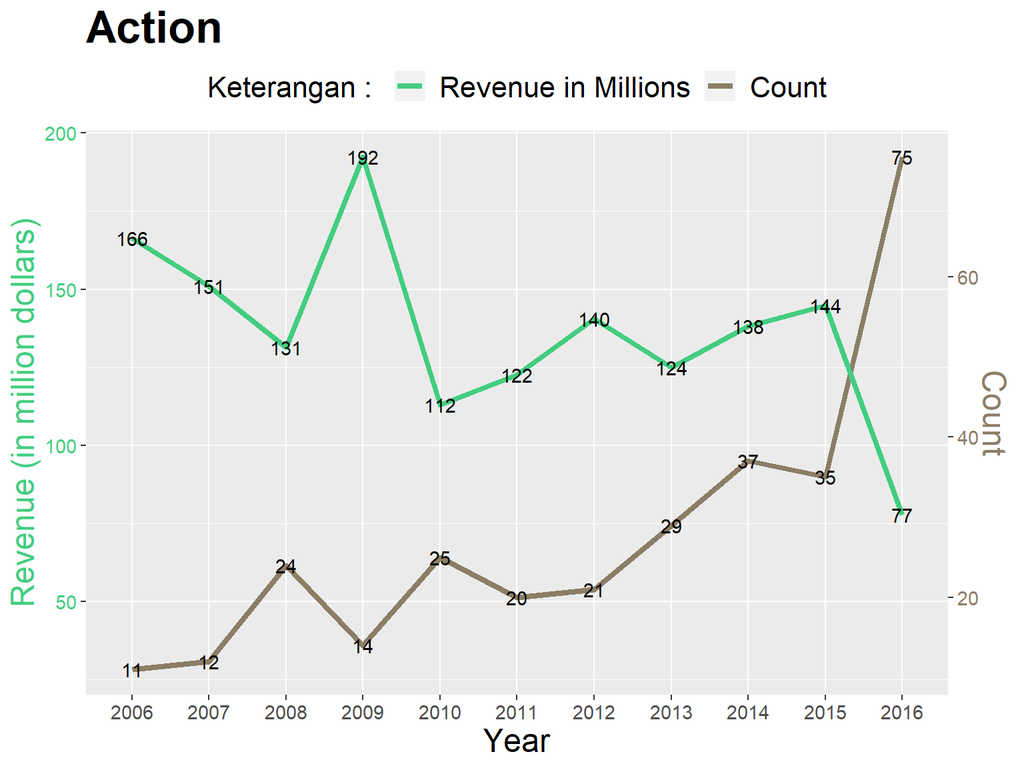

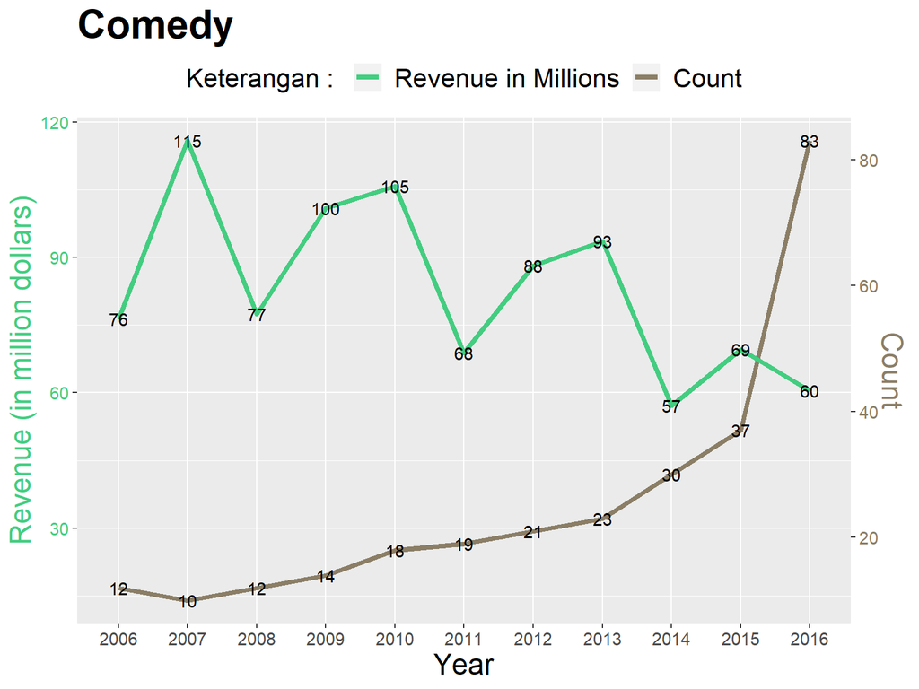

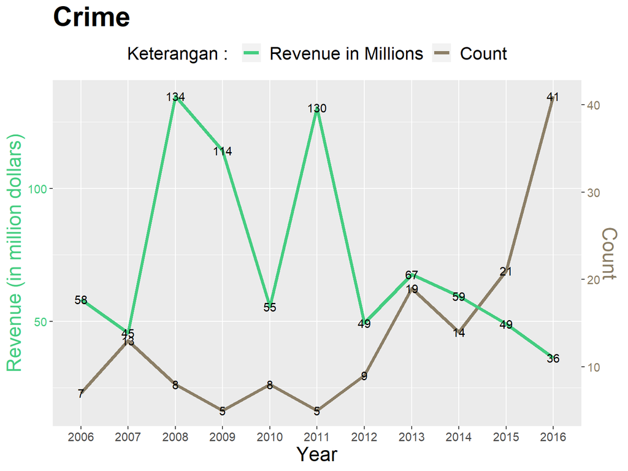

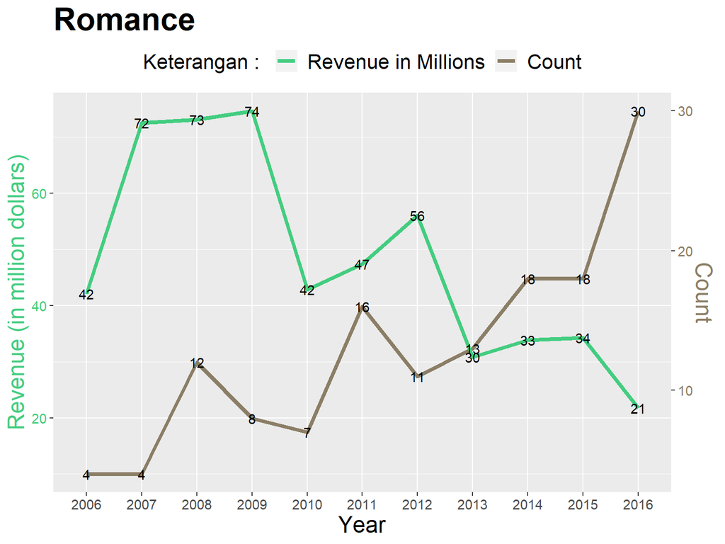

# Penyiapan Data (4)

Buat dataframe untuk menghitung jumlah film yang dihasilkan untuk tiap genre dari seluruh tahun, dan nilai rata-rata pendapatannya

```r
dataGenreTotal <- dataGenreYear %>%
  group_by(Genre) %>%
  summarise(Count = sum(Count), MeanRev = mean(MeanRev, na.rm = TRUE))

dataGenreTotal
```

| Genre | Count | MeanRev |
| --- | --- | --- |
| Action | 303 | 136.62939 |
| Adventure | 259 | 158.66914 |
| Animation | 49 | 205.80525 |
| Biography | 81 | 73.33039 |
| Comedy | 279 | 83.10971 |
| Crime | 150 | 72.77580 |
| Drama | 513 | 58.39850 |
| Family | 51 | 132.32010 |
| Fantasy | 101 | 139.90711 |
| History | 29 | 52.52961 |

[output cut: 10 more lines]

# Analisis Data (3)

Selain itu juga, kami membuat barplot horizontal yang menunjukkan rata-rata revenue film. Untuk y-label adalah genre film. Untuk x-label menggunakan rata-rata revenue yang dihasilkan dengan satuan juta dollar. Berikut barplot yang kami buat:

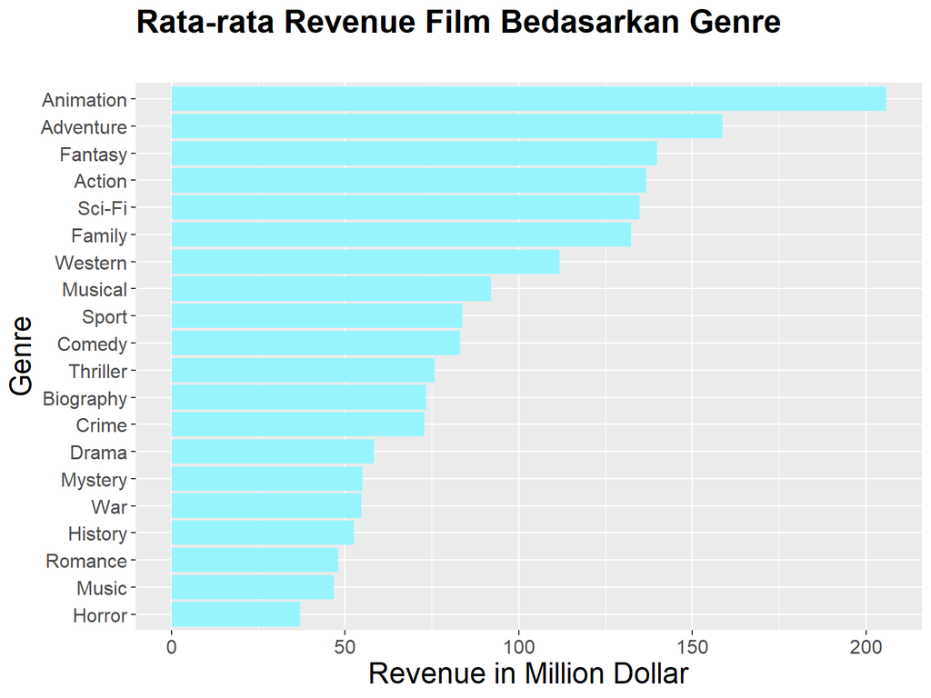

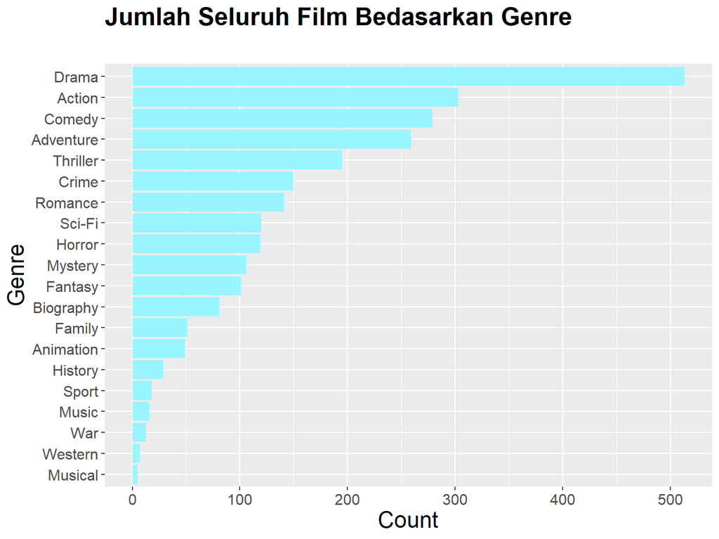

```r
#Rata-rata pendapatan
ggplot(dataGenreTotal, aes(x = reorder(Genre, MeanRev), y = MeanRev))+
    geom_bar(stat = 'identity', fill = 'cadetblue1')+
    coord_flip()+
    xlab("Genre")+
  ylab("Revenue in Million Dollar")+
  theme(axis.text=element_text(size=12), axis.title=element_text(size=18), plot.title = element_text(size = 20, face = "bold"))+
    ggtitle("Rata-rata Revenue Film Bedasarkan Genre\n")

#Jumlah film di Produksi
ggplot(dataGenreTotal, aes(x = reorder(Genre, Count), y = Count))+
  geom_bar(stat = 'identity', fill = 'cadetblue1')+
    coord_flip()+
    xlab("Genre")+
  ylab("Count")+
  theme(axis.text=element_text(size=12), axis.title=element_text(size=18), plot.title = element_text(size = 20, face = "bold"))+
  ggtitle("Jumlah Seluruh Film Bedasarkan Genre\n")
```

# Insight dan Manfaat

Dari hasil analisis, kami mendapatkan insight sebagai berikut:

- Film animasi lebih banyak menghasilkan uang ( dilihat dari pehitungan rata-rata revenue ) dari genre manapun. Film Adventure juga menjadi film kedua dengan rata-rata revenue yang tinggi. Film Horror memiliki rata-rata revenue yang paling rendah dari seluruh genre.
- Di beberapa kasus, semakin banyak film yang diproduksi rata-rata pendapatan yang diperoleh semakin kecil.

# Kesimpulan

Dari insight-insight yang kami dapatkan, keputusan bisnis yang dapat dilakukan:

- Dari analisis pertama, didapatkan kesimpulan
  - Pihak manajemen bioskop dapat membuka slot kuota penayangan lebih banyak lagi untuk film yang bergenre Drama, Action, dan juga Comedy dibandingkan film-film Musical, Western, maupun War. Hal ini akan membuat bioskop lebih ramai dan menggaet lebih banyak penonton.
  - Pihak produksi film yang baru-baru dibuat seperti A24 bisa lebih memilih genre Drama maupun Action untuk meningkatkan popularitas rumah produksi mereka
- Dari analisis kedua, didapatkan kesimpulan:
  - Pihak produksi film dapat lebih memilih Animation, Adventure ataupun Sci-Fi untuk mendapatkan pendapatan yang tinggi dibandingkan film genre yang lain seperti Horror, Romance, dan Music.
  - Pihak produksi dapat untuk menghindari merilis film di tahun itu, jika pada tahun tersebut terdapat banyak film lain dengan Genre yang sama. Akan lebih baik untuk menggeser jadwal tayangnya karena memungkinkan untuk lebih menguntungkan dari segi pendapatan.

# 2. Apakah seorang Sutradara (Director) cenderung bekerjasama dengan Aktor-aktor yang sama.

Kami ingin mencari tahu seberapa sering seorang sutradara bekerjasama dengan aktor yang sama lebih dari satu kali.

Diperlukan tabel sebagai berikut:

- DataActorDirector(Director, Actor, CountFilm)

Keterangan:

- - Director : Sutradara dari film
  - Actor : Aktor film
  - CountFilm : Jumlah Film yang disutradarai dan dimainkan

# Penyiapan Data

Dari dataframe yang setiap baris di kolom Actor-nya memiliki lebih dari satu aktor, akan dibuat 4 kolom baru (jumlah actor yang tertulis untuk satu film tidak mungkin melebihi 4). Setiap kolom baru yang dibuat (Actor1, Actor2, Actor3, Actor4) akan berisi hasil pemisahan Actors.

```r
#Import ulang dataset yang digunakan
data <- read.csv("IMDB-Movie-Data.csv")

i <- 1
while (i <= nrow(data)) {
  Actors <- unlist(strsplit(data$Actors[i], ",", fixed = TRUE))
  data$Actor1[i] <- Actors[1]
  data$Actor2[i] <- Actors[2]
  data$Actor3[i] <- Actors[3]
  data$Actor4[i] <- Actors[4]
  i <- i + 1
}

#Tampilkan kolom: Title, Genre, Genre1, Genre2, Genre3
head(data %>% select(Title, Actors, Actor1, Actor2, Actor3, Actor4) %>% arrange(Title))
```

|  | Title | Actors | Actor1 | Actor2 | Actor3 | Actor4 |
| --- | --- | --- | --- | --- | --- | --- |
| 1 | (500) Days of Summer | Zooey Deschanel, Joseph Gordon-Levitt, Geoffrey Arend, Chloë Grace Moretz | Zooey Deschanel | Joseph Gordon-Levitt | Geoffrey Arend | Chloë Grace Moretz |
| 2 | 10 Cloverfield Lane | John Goodman, Mary Elizabeth Winstead, John Gallagher Jr., Douglas M. Griffin | John Goodman | Mary Elizabeth Winstead | John Gallagher Jr. | Douglas M. Griffin |
| 3 | 10 Years | Channing Tatum, Rosario Dawson, Chris Pratt, Jenna Dewan Tatum | Channing Tatum | Rosario Dawson | Chris Pratt | Jenna Dewan Tatum |
| 4 | 12 Years a Slave | Chiwetel Ejiofor, Michael Kenneth Williams, Michael Fassbender, Brad Pitt | Chiwetel Ejiofor | Michael Kenneth Williams | Michael Fassbender | Brad Pitt |
| 5 | 127 Hours | James Franco, Amber Tamblyn, Kate Mara, Sean Bott | James Franco | Amber Tamblyn | Kate Mara | Sean Bott |
| 6 | 13 Hours | John Krasinski, Pablo Schreiber, James Badge Dale,David Denman | John Krasinski | Pablo Schreiber | James Badge Dale | David Denman |

# Penyiapan Data (2)

Buat dataframe baru dengan menggabungkan Aktor dari 4 kolom ke satu kolom dengan menambahkan 1 baris untuk tiap Aktor. Untuk film yang memiliki lebih dari 1 aktor akan muncul sebanyak jumlah genre yang dimiliki film tersebut.

```r
dataActor1 <- data.frame(data$Title, data$Year, data$Director, data$Actor1)
colnames(dataActor1) <- c("Title", "Year", "Director", "Actor")

dataActor2 <- data.frame(data$Title, data$Year, data$Director, data$Actor2)
colnames(dataActor2) <- c("Title", "Year", "Director", "Actor")
dataActor2 <- dataActor2 %>% drop_na(Actor)

dataActor3 <- data.frame(data$Title, data$Year, data$Director, data$Actor3)
colnames(dataActor3) <- c("Title", "Year", "Director", "Actor")
dataActor3 <- dataActor3 %>% drop_na(Actor)

dataActor4 <- data.frame(data$Title, data$Year, data$Director, data$Actor4)
colnames(dataActor4) <- c("Title", "Year", "Director", "Actor")
dataActor4 <- dataActor4 %>% drop_na(Actor)

dataActor <- bind_rows(dataActor1, dataActor2, dataActor3, dataActor4)
head(dataActor %>% arrange(Title))
```

|  | Title | Year | Director | Actor |
| --- | --- | --- | --- | --- |
| 1 | (500) Days of Summer | 2009 | Marc Webb | Zooey Deschanel |
| 2 | (500) Days of Summer | 2009 | Marc Webb | Joseph Gordon-Levitt |
| 3 | (500) Days of Summer | 2009 | Marc Webb | Geoffrey Arend |
| 4 | (500) Days of Summer | 2009 | Marc Webb | ChloÃ« Grace Moretz |
| 5 | 10 Cloverfield Lane | 2016 | Dan Trachtenberg | John Goodman |
| 6 | 10 Cloverfield Lane | 2016 | Dan Trachtenberg | Mary Elizabeth Winstead |

# Penyiapan Data (3)

Kelompokkan data berdasarkan Director dan aktor, lalu hitung jumlah film yang disutradarai dan dimainkan. Hanya akan digunakan sutradara yang sudah membuat lebih dari 1 film.

```r
dataActorDirector <- inner_join(dataActor %>% group_by(Director) %>% summarise(Count = n_distinct(Title)) %>% filter(Count > 1), dataActor, by = "Director") %>%
                        group_by(Director, Actor) %>%
                        summarise(CountFilm = n())

dataActorDirector %>% arrange(CountFilm)
```

| Director | Actor | CountFilm |
| --- | --- | --- |
| Adam McKay | Brad Pitt | 1 |
| Adam McKay | Derek Jeter | 1 |
| Adam McKay | Eva Mendes | 1 |
| Adam McKay | Gary Cole | 1 |
| Adam McKay | Mark Wahlberg | 1 |
| Adam McKay | Mary Steenburgen | 1 |
| Adam McKay | Ryan Gosling | 1 |
| Adam McKay | Sacha Baron Cohen | 1 |
| Adam McKay | Steve Carell | 1 |
| Adam McKay | Christian Bale | 1 |

[output cut: 2056 more lines]